# GLM para dados binários

Samuel Lima & Niege Félix

# 1 Introdução

Carregando pacotes a serem utilizados e importando o banco de dados

```r
library(ggplot2)
library(dplyr)
library(DHARMa)
library(performance)

bd1 <- read.csv("../Dados/bd_geral_com_traits.csv")
```

Para exercitar o GLM para dados binários vamos utilizar os dados coletados como parte da pesquisa de mestrado do Samuel Lima (UFRN).

O banco de dados trata-se de insetos coletados em árvores plantadas de um experimento de biodiversidade e funcionamento de ecossistemas focado na restauração da Caatinga. A coleta foi realizada manualmente, por busca ativa, no final da estação chuvosa de 2023.

Saiba mais do experimento [aqui](https://brazildry.wixsite.com/treediv).

Nosso **objetivo** aqui será testar se a riqueza de espécies e o tipo de interação entre árvores, assim como a abundância de presas, afetam a incidência de insetos predadores no semiárido brasileiro. Temos como **hipóteses**, $H_1:$ A riqueza de espécies e o potencial de facilitação de árvores influenciam positivamente a incidência de insetos predadores; $H_2:$ A abundância de insetos não predadores (presas) influencia positivamente a incidência de insetos predadores.

# 2 Análise exploratória

Vamos iniciar filtrando as variáveis de interesse e observando a natureza (*character*, *factor*, *numeric*, *integer*, etc.) que cada variável foi importada:

```r
bd1 <- dplyr::select(bd1,c("plot","div","Abund","Food_guild"))

str(bd1)
```

```
## 'data.frame':    740 obs. of  4 variables:
##  $ plot      : int  1 1 1 1 1 1 1 2 2 2 ...
##  $ div       : int  1 1 1 1 1 1 1 1 1 1 ...
##  $ Abund     : int  31 2 1 1 1 1 1 18 12 6 ...
##  $ Food_guild: chr  "predator" "herbivore" "predator" "herbivore" ...
```

Olhando a estrutura dos dados, percebemos que precisamos converter as variáveis do tipo *character* e a variável `plot` em *fator*

## 2.1 Corrigindo os tipos de variáveis

```r
bd1[, c("plot","Food_guild")] <- lapply(bd1[, c("plot","Food_guild")], factor)
```

Vamos adaptar o nosso banco de dados para conseguir trabalhar com o modelo logístico

## 2.2 Criando o dado binário

```r
levels(bd1$Food_guild)
```

```
## [1] "detritivores"   "haematophagous" "herbivore"      "nectarivores"
## [5] "parasitoid"     "predator"
```

Temos seis tipos de guilda alimentar. Vamos transformar cada tipo em uma variável de interesse (colunas) de presença e ausência (1,0):

```r
bd1$predadores <- ifelse(bd1$Food_guild == "predator",1, 0)
bd1$herbivoros <- ifelse(bd1$Food_guild == "herbivore",1, 0)
bd1$detritivoros <- ifelse(bd1$Food_guild == "detritivores",1, 0)
bd1$parasitoides <- ifelse(bd1$Food_guild == "parasitoid",1, 0)
bd1$nectarivoros <- ifelse(bd1$Food_guild == "nectarivores",1, 0)
bd1$hematofagos <- ifelse(bd1$Food_guild == "haematophagous",1, 0)

head(bd1[,5:10]) #Observando apenas as colunas recém criadas
```

```
##   predadores herbivoros detritivoros parasitoides nectarivoros hematofagos
## 1          1          0            0            0            0           0
## 2          0          1            0            0            0           0
## 3          1          0            0            0            0           0
## 4          0          1            0            0            0           0
## 5          0          1            0            0            0           0
## 6          0          1            0            0            0           0
```

Conhecendo mais o nosso banco de dados, vamos observar o número de morfotipos de insetos por guilda alimentar e agrupado por nível de riqueza de espécies de árvores

```
##   Nherbivoros Npredadores Ndetritivoros Nparasitoides Nnectarivoros
## 1         439         229            43             9            17
##   Nhematofagos
## 1            3
```

```
## # A tibble: 5 × 7
##     div Nherbivoros Npredadores Ndetritivoros Nparasitoides Nnectarivoros
##   <int>       <dbl>       <dbl>         <dbl>         <dbl>         <dbl>
## 1     1         145          81            17             2             4
## 2     2         133          70            17             2             8
## 3     4          70          31             4             0             3
## 4     8          34          23             2             1             1
## 5    16          57          24             3             4             1
## # ℹ 1 more variable: Nhematofagos <dbl>
```

Proporção de predadores e não predadores (herbivoros e demais):

```
## # A tibble: 5 × 4
##     div Npredadores N_naopredadores Prop_pred_naopred
##   <int>       <dbl>           <dbl>             <dbl>
## 1     1          81             169             0.479
## 2     2          70             161             0.435
## 3     4          31              78             0.397
## 4     8          23              38             0.605
## 5    16          24              65             0.369
```

Para finalizar a preparação do nosso banco de dados, vamos adicionar algumas variáveis de interesse de um outro banco de dados do mesmo estudo e agrupá-las pela réplica do experimento BrazilDry (as parcelas).

```r
bd2 <- read.csv("../Dados/bd_analises.csv")
bd2$plot<-as.factor(bd2$plot)

pred <- bd2 %>%
        select(plot,facilitation,composition,mean_height,mean_canopy_diam)

bd1<-inner_join(bd1,pred,by="plot")

#Criando uma coluna de abundância de não predadores
bd1$Abund_semp <- ifelse(bd1$Food_guild == "predator",0,bd1$Abund)

bd3<- bd1 %>%                        #Agrupamento
      group_by(plot) %>%
      summarise(facilitation=unique(facilitation),
      composition=unique(composition),
      mean_height=unique(mean_height),
      mean_canopy_diam=unique(mean_canopy_diam),
      div=unique(div),
      Abundanciag=sum(Abund),
      Abundancianaop=sum(Abund_semp),
      Abundanciap=sum(predadores)) %>%
      mutate(pres_predadores=ifelse(Abundanciap > 0,1,0))
```

Agora sim, podemos começar a visualizar algumas relações:

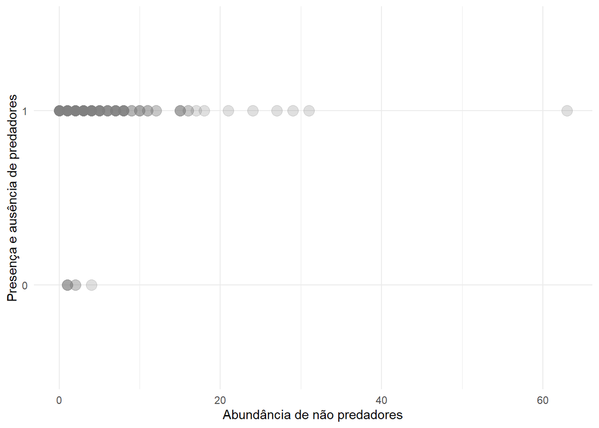

```r
## Presença e ausência de predadores vs Abundância de não predadores
ggplot(bd3, aes(x = Abundancianaop, y = factor(pres_predadores))) +
  geom_point(size = 4, col = 'gray50', alpha = 0.25) +
  scale_y_discrete(name = "Presença e ausência de predadores")+
  scale_x_continuous(name = "Abundância de não predadores")+
  theme_minimal()
```

Aparentemente há uma tendência da presença de predadores nas parcelas com maior abundância de insetos não predadores (generalizados aqui como presas). Porém, os predadores também estavam presentes nas parcelas com baixa abundância de não predadores e apenas 7 parcelas apresentaram ausência de predadores.

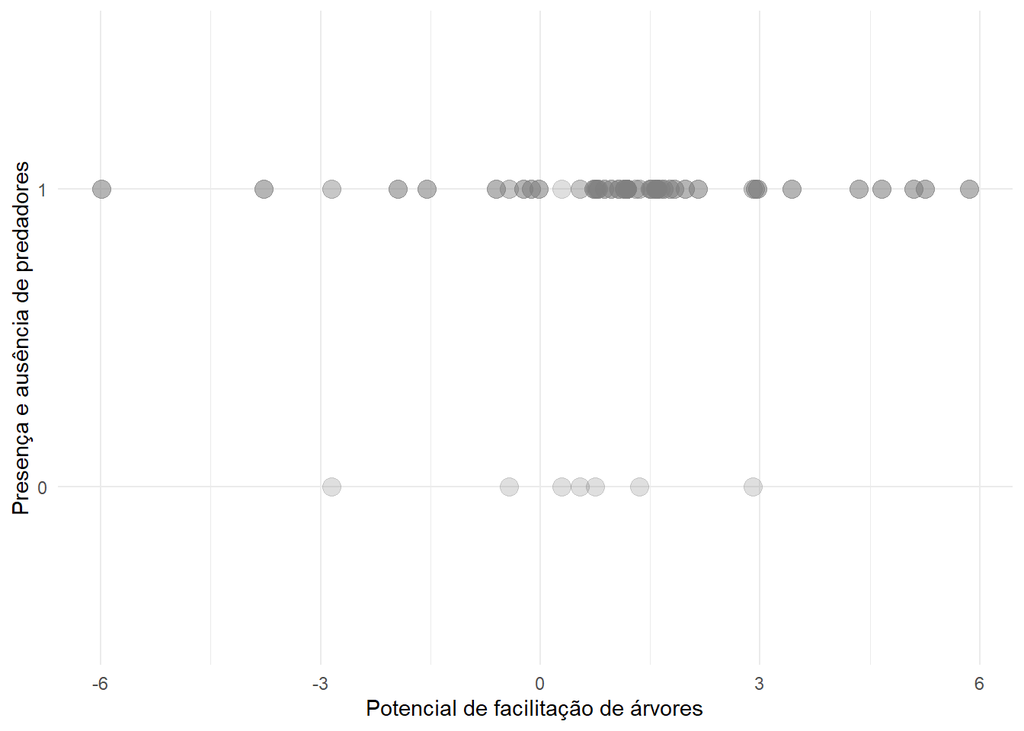

```r
##  Presença e ausência de predadores vs facilitação de árvores
ggplot(bd3, aes(x = facilitation, y = factor(pres_predadores))) +
  geom_point(size = 4, col = 'gray50', alpha = 0.25) +
  scale_y_discrete(name = "Presença e ausência de predadores")+
  scale_x_continuous(name = "Potencial de facilitação de árvores")+
  theme_minimal()
```

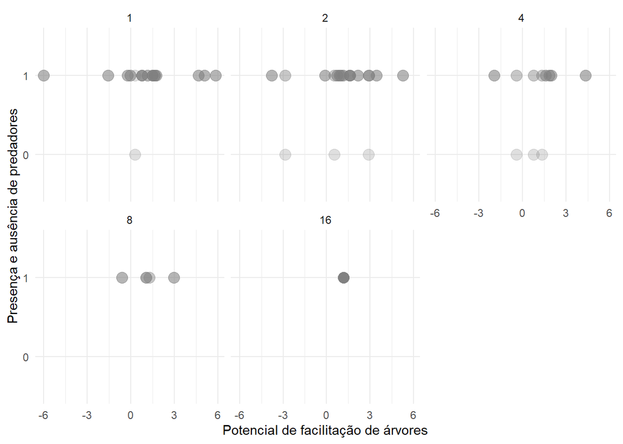

```r
## Presença e ausência de predadores vs facilitação de árvores separado por nível de riqueza de espécies
ggplot(bd3, aes(x = facilitation, y = factor(pres_predadores))) +
  geom_point(size = 4, col = 'gray50',alpha = 0.25) +
  scale_y_discrete(name = "Presença e ausência de predadores")+
  scale_x_continuous(name = "Potencial de facilitação de árvores")+
  facet_wrap(factor(div) ~ .) +
  theme_minimal()
```

Aqui vemos uma pequena tendência para um efeito interativo entre a riqueza de espécies de árvores e a facilitação. Onde os predadores estiveram ausêntes apenas nos três primeiros níveis de riqueza de espécies e as presenças observadas quando o potencial de facilitação é negativo (competição) tendem a diminuir com o aumento da riqueza de espécies de árvores.

# 3 Metodologia

Para avaliar os fatores que influenciam a presença de insetos predadores, será utilizado um modelo de regressão logística (i.e., modelo binomial), visto que a variável resposta (*pres_predadores*) é binária (presença (1) vs. ausência (0)).

Podemos resumir o modelo conforme:

$$y_i \sim Binomial(n_i, p_i)$$

$$logit(p_i) = \eta_i
= \beta_0 +\sum_{j=1}^{J} \beta_j x_{ij}$$

onde $y_i$ é o i*esmo* inseto predador, $n_i$ o número total de insetos predadores, $p_i$ a probabilidade do i*esmo* inseto predador estar presente nas comunidades experimentais (parcelas), $\beta_0$ o intercepto, $j$ número de covariáveis, $\beta_j$ os coeficientes que quantificam o efeito das covariáveis $x_j$.

Poderíamos escrever o modelo completo, conforme:

$$logit(p_i) = \beta_0 + \sum_{j=1}^{J-1}
\beta_j RiquezaSp_{i,j} + \sum_{k=1}^{K-1} \gamma_k Facilitacao_{i,k} +
\sum_{l=1}^{L-1} \nu_l AbundanciaPresas_{i,l}$$

> O modelo contém 3 covariáveis numéricas, portanto, trata-se de uma regressão múltipla com uma distribuição binomial!

Vamos testar diversos modelos para achar o modelo que melhor se ajuste aos dados. Para tanto, usaremos o método “forward-stepwise”, em que partimos do modelo nulo e inserimos uma covariável por vez.

Os modelos serão comparados pelos valores de AIC e o ajuste dos modelos será analisado via análises gráficas dos resíduos.

## 3.1 Escalando as variáveis preditoras

```r
cols<-c("div", "facilitation","mean_height","mean_canopy_diam","Abundancianaop")
bd3[,cols] <- scale(bd3[,cols], scale=T, center=F)
```

## 3.2 Selecionando o modelo

```r
## Modelo Nulo
mod0 <- glm(factor(pres_predadores) ~ 1,
            family = binomial(link = "logit"),
            data = bd3)

## Modelo 1
mod1 <- glm(factor(pres_predadores) ~ div,
            family = binomial(link = "logit"),
            data = bd3)

## Modelo 2
mod2 <- glm(factor(pres_predadores) ~ div + facilitation,
            family = binomial(link = "logit"),
            data = bd3)

## Modelo 3
mod3 <- glm(factor(pres_predadores) ~ div + facilitation + Abundancianaop,
            family = binomial(link = "logit"),
            data = bd3)

## Modelo 4
mod4 <- glm(factor(pres_predadores) ~ div * facilitation + Abundancianaop,
            family = binomial(link = "logit"),
            data = bd3)


# Extraindo o Akaike's Information Criterion
aic <- AIC(mod0, mod1, mod2, mod3, mod4)

## Ordenando do melhor ao pior modelo ##
aic %>% arrange(AIC)
```

```
##      df      AIC
## mod3  4 56.06890
## mod4  5 57.88483
## mod0  1 57.88869
## mod1  2 59.24797
## mod2  3 60.34255
```

O modelo que usou todas as covariávies de forma aditiva (mod3) foi o que apresentou o melhor ajuste, uma vez que apresentou o menor valor de AIC quando comparado aos demais modelos. Além disso, não há diferença expressiva entre ele e o segundo e o terceiro melhor modelo.

Vamos agora analisar graficamente o ajuste do modelo:

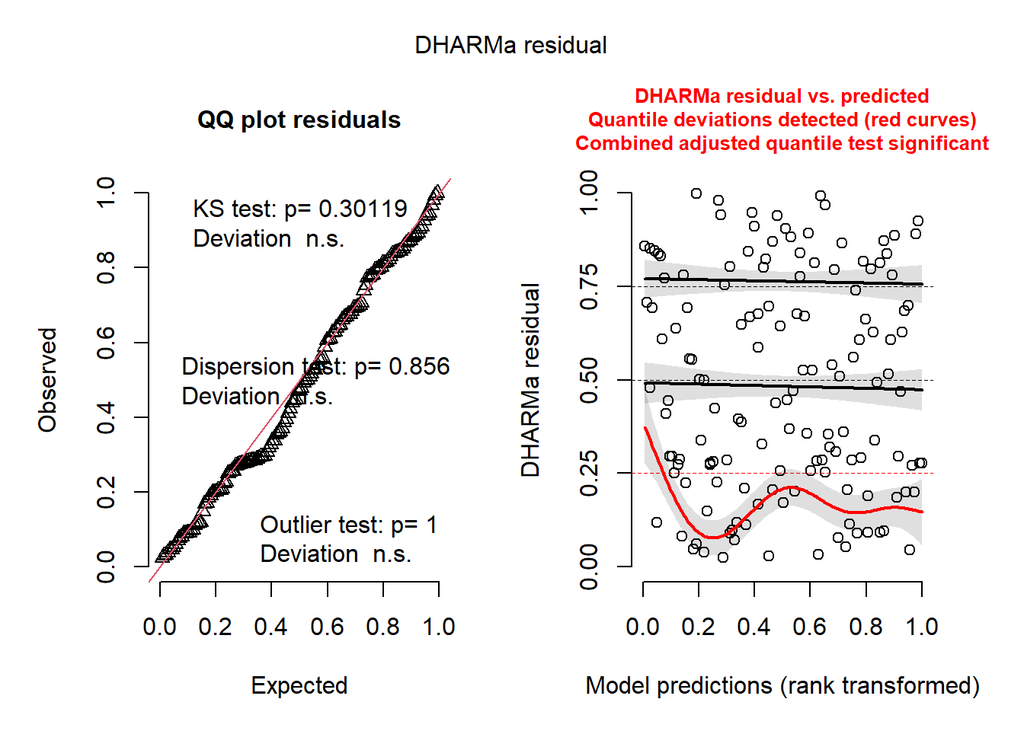

```r
resid_sim <- simulateResiduals(mod3, n=1000)
plot(resid_sim)
```

Houve um pequeno desvio em um dos quartis dos resíduos, mas no geral o modelo está adequado. Por fim, vamos checar a autocorrelação dos resíduos

```r
check_autocorrelation(mod3)
```

[output not shown]

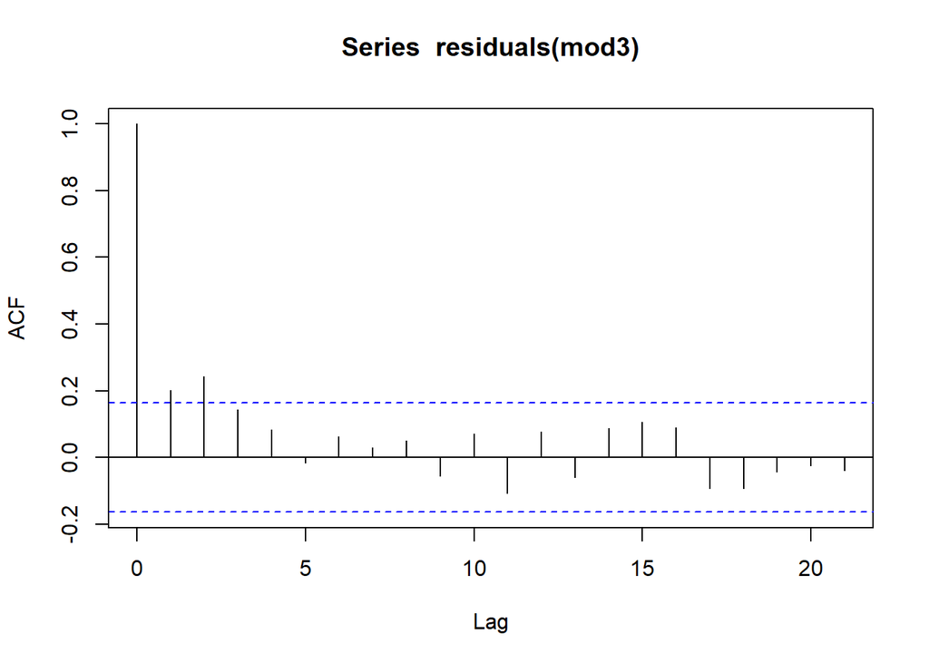

```r
acf(residuals(mod3))
```

Houve uma pequena violação, mas ela se mostra mínima e provavelmente não influencia a inferência do modelo. Portanto, podemos seguimos para a análise dos resultados!

# 4 Resultados

```r
summary(mod3)
```

```
##
## Call:
## glm(formula = factor(pres_predadores) ~ div + facilitation +
##     Abundancianaop, family = binomial(link = "logit"), data = bd3)
##
## Coefficients:
##                Estimate Std. Error z value Pr(>|z|)
## (Intercept)      1.4478     0.6780   2.135   0.0327 *
## div              0.4117     0.8097   0.508   0.6111
## facilitation     0.2544     0.4191   0.607   0.5438
## Abundancianaop   3.8877     2.1329   1.823   0.0684 .
## ---
## Signif. codes:  0 '***' 0.001 '**' 0.01 '*' 0.05 '.' 0.1 ' ' 1
##
## (Dispersion parameter for binomial family taken to be 1)
##
##     Null deviance: 55.889  on 142  degrees of freedom
## Residual deviance: 48.069  on 139  degrees of freedom
## AIC: 56.069
##
## Number of Fisher Scoring iterations: 8
```

Os coeficientes de cada variável nos diz o quanto a incidência de insetos predadores aumenta com o aumento de uma espécies de árvores, porém, na escala LOGIT.

Por se tratar de um modelo logístico, todos os parâmetros estão expressos na escala logit e são interpretados sob a forma de *razão de chance*. Esses parâmetros podem ser transformados em probabilidades convertendo-os para escala natural conforme:

$$p = \frac{1}{1 +
exp(-\eta)}$$